# Project 2

Hannah Dean

2025-10-24

## 1 Design & Simulation

#### 1.0.1 Topic & Rationale

Spin Rate Tiers Effect on Exit Velocity

Does exit velocity differ across spin rater tiers (Low, Medium, High) and between batter handedness (Left vs Right)? Does the effect of spin rate on exit velocity depend on batter handiness?

Main Effect Spin Rate Tier

Main Effect Batter Handiness

Internationale Effect (Spin Rate Tiers x Batter Handiness)

- **H₀₃:** There is no interaction between spin-rate tier and batter handedness.  
  The effect of spin rate on exit velocity is the same for both left- and right-handed batters.
- **H₁₃:** There is a significant interaction.  
  The relationship between spin rate and exit velocity changes depending on batter handedness.

#### 1.0.2 Factor Definition

Factor A: (Spin Rate Tiers) by Quantile • Low SR • Medium SR • High SR

Factor B: (Batter Handiness) • Left • Right

All 6 treatments: LSRleft, LSRright, MSRleft, MSRright, HSRleft, HSRright

#### 1.0.3 Data Construction

```r
# ---- Packages ----
library(vroom)
library(dplyr)
library(stringr)
library(lubridate)
library(purrr)
library(tibble)
library(readr)
library(tidyr)
library(multcomp)
```

```r
library(ggplot2)

# "C:\Users\hanna\OneDrive\Documents\Pionneer League Games 2025"
#"C:\\Users\\hanna\\OneDrive\\Documents\\Pioneer League Games 2025"

# ---- Find all official games in "Pioneer League Games 2025" File ----
#base_dir <- (choose.dir(caption = "Select the 'Pioneer League Games 2025' folder"))

base_dir <- ("C:\\Users\\hanna\\OneDrive\\Documents\\Pionneer League Games 2025")

list_official_csvs <- function(base_dir, strict_structure = TRUE) {
  all_csvs <- list.files(base_dir, pattern = "\\.csv$", recursive = TRUE, full.names = TRUE, ignore.case = TRUE)
  cat("Total .csv found (anywhere under base):", length(all_csvs), "\n")

  # Must be inside .../(5..9 or 05..09)/(day)/CSV/...
  if (strict_structure) {
    under_csv <- grepl("[/\\\\](0?[5-9])[/\\\\]\\d{1,2}[/\\\\]CSV[/\\\\]", all_csvs, ignore.case = TRUE)
  } else {
    # Relaxed: anywhere there is a CSV folder in the path
    under_csv <- grepl("[/\\\\]CSV[/\\\\]", all_csvs, ignore.case = TRUE)
  }
  cat("…in CSV folders with month/day structure:", sum(under_csv), "\n")

  # Official filename: YYYYMMDD-Field-Game#.csv  (case-insensitive)
  fname <- basename(all_csvs)
  looks_official <- grepl("^\\d{8}-[^-]+-\\d+\\.csv$", fname, ignore.case = TRUE)
  cat("…matching official filename pattern:", sum(looks_official), "\n")

  # Exclude any *_unverified* variants in "CSV" folder
  not_unverified <- !grepl("_unverified", fname, ignore.case = TRUE)
  cat("…excluding _unverified:", sum(not_unverified), "\n")

  keep <- under_csv & looks_official & not_unverified
  files <- sort(all_csvs[keep])
  cat("Official files kept:", length(files), "\n")

  if (length(files) == 0) {
    cat("\nNo matches. Quick hints:\n",
        "- Check that month folders are 5..9 or 05..09.\n",
        "- Ensure there is a 'CSV' folder (exact name, any case) at the 3rd level.\n",
        "- Confirm filenames look like 20250902-DehlerPark-1.csv (no spaces, hyphens exactly).\n",
        "- If your structure differs, set strict_structure = FALSE.\n", sep = "")
  }
  files
}

# ---- Run the finder ----
official_files <- list_official_csvs(base_dir, strict_structure = TRUE)
```

```
## Total .csv found (anywhere under base): 1819
## …in CSV folders with month/day structure: 1810
## …matching official filename pattern: 574
## …excluding _unverified: 583
## Official files kept: 574
```

```r
# If you get 0, try relaxed search:
if (length(official_files) == 0) {
  cat("\nRetrying with relaxed structure (any 'CSV' folder)…\n")
  official_files <- list_official_csvs(base_dir, strict_structure = FALSE)
}

# ---- Balls in Play ----
# We just want rows where there is a ball in play so create new spreadsheet with
# value: "InPlay" in variable:"PitchCall"

pbl_official <- vroom::vroom(
  official_files,
  .name_repair = "unique",
  altrep = TRUE,
  id = "source_file",
  progress = TRUE
) %>%
  mutate(
    file_name     = basename(source_file),
    game_date_chr = str_match(file_name, "^(\\d{8})-")[,2],
    field         = str_match(file_name, "^\\d{8}-([^-]+)-\\d+\\.csv$")[,2],
    game_no       = suppressWarnings(as.integer(str_match(file_name, "-(\\d+)\\.csv$")[,2])),
    game_date     = suppressWarnings(lubridate::ymd(game_date_chr))
  ) %>%
  dplyr::select(source_file, file_name, game_date, field, game_no, dplyr::everything())
```

[output not shown]

```r
# column grabber for "PitchCall"
col_like <- function(df, target) {
  nm <- names(df)
  hit <- which(tolower(gsub("\\s+", "", nm)) == tolower(gsub("\\s+", "", target)))
  if (length(hit) == 0) return(NA_character_)
  nm[hit[1]]
}
pc_col <- col_like(pbl_official, "PitchCall")
if (is.na(pc_col)) stop("Couldn't find a 'PitchCall' column in pbl_official.")

# Filter InPlay and write CSV
out_dir <- file.path(base_dir, "Outputs")
if (!dir.exists(out_dir)) dir.create(out_dir, recursive = TRUE)

all_inplay <- pbl_official %>%
  filter(!is.na(.data[[pc_col]])) %>%
  mutate(!!pc_col := trimws(.data[[pc_col]])) %>%
  filter(.data[[pc_col]] == "InPlay")

out_path <- file.path(out_dir, "PioneerLeague_InPlay_AllRows.csv")
readr::write_csv(all_inplay, out_path)

cat("Saved", nrow(all_inplay), "rows to:\n", out_path, "\n")
```

```
## Saved 32393 rows to:
##  C:\Users\hanna\OneDrive\Documents\Pionneer League Games 2025/Outputs/PioneerLeague_InPlay_AllRows.csv
```

```r
# ---- Edited Variables ----
# Edit Data so it only has Variables needed for research

# Required Variables
required <- c(
  "BatterSide","PitcherThrows","SpinRate","AutoPitchType","ExitSpeed","Angle",
  "RelSpeed","ZoneSpeed","PlateLocHeight","PlateLocSide","AutoHitType",
  "Direction","HitSpinRate"
)

# Make the trimmed tibble in memory
stopifnot(exists("all_inplay"))
missing <- setdiff(required, names(all_inplay))
if (length(missing)) stop(paste("Missing columns in `all_inplay`:", paste(missing, collapse=", ")))

inplay_var <- dplyr::select(all_inplay, all_of(required))

# Quick peek
glimpse(inplay_var)
```

```
## Rows: 32,393
## Columns: 13
## $ BatterSide     <chr> "Right", "Left", "Right", "Left", "Right", "Right", "Le…
## $ PitcherThrows  <chr> "Left", "Left", "Left", "Left", "Right", "Right", "Righ…
## $ SpinRate       <dbl> 2396.031, 2603.102, 2607.367, 2497.545, 1973.796, 2086.…
## $ AutoPitchType  <chr> "Four-Seam", "Slider", "Slider", "Four-Seam", "Changeup…
## $ ExitSpeed      <dbl> 76.46613, 67.81783, 98.41348, 96.65537, 89.97362, 61.22…
## $ Angle          <dbl> 56.571275, 41.169473, 7.733660, 69.696922, 16.714628, 3…
## $ RelSpeed       <dbl> 88.59854, 83.56476, 82.70701, 88.25936, 86.12767, 87.68…
## $ ZoneSpeed      <dbl> 78.19942, 75.62261, 75.67537, 79.18868, 77.88824, 79.37…
## $ PlateLocHeight <dbl> 3.12864, 2.01537, 1.85028, 2.95716, 2.29249, 2.62080, 2…
## $ PlateLocSide   <dbl> -0.62336, 0.67138, -1.00722, -0.20804, 0.41637, 0.62413…
## $ AutoHitType    <chr> "Popup", "FlyBall", "LineDrive", NA, "LineDrive", "FlyB…
## $ Direction      <dbl> 34.153277, -3.823004, 15.493259, 42.804554, 20.267862, …
## $ HitSpinRate    <dbl> NA, 3899.505, 1652.213, NA, 3783.421, 3822.875, NA, 204…
```

```r
nrow(inplay_var); ncol(inplay_var); names(inplay_var)
```

```
## [1] 32393
```

```
## [1] 13
```

```
##  [1] "BatterSide"     "PitcherThrows"  "SpinRate"       "AutoPitchType"
##  [5] "ExitSpeed"      "Angle"          "RelSpeed"       "ZoneSpeed"
##  [9] "PlateLocHeight" "PlateLocSide"   "AutoHitType"    "Direction"
## [13] "HitSpinRate"
```

```r
# (Optional) Save it too
out_dir <- file.path(base_dir, "Outputs")
if (!dir.exists(out_dir)) dir.create(out_dir, recursive = TRUE)
out_path <- file.path(out_dir, "PioneerLeague_InPlay_SelectedCols_STRICT.csv")
write_csv(inplay_var, out_path)
cat("Saved:", out_path, "\n")
```

```
## Saved: C:\Users\hanna\OneDrive\Documents\Pionneer League Games 2025/Outputs/PioneerLeague_InPlay_SelectedCols_STRICT.csv
```

```r
# ---- Delete NA's ----
# Get rid of rows with NA's

inplay_var_clean <- inplay_var %>%
  # 1) Trim and convert "" -> NA ONLY for character columns
  mutate(across(where(is.character), ~ na_if(trimws(.), ""))) %>%
  # 2) (Optional) Parse obvious numeric columns that might have come in as text
  mutate(across(c(SpinRate, ExitSpeed, Angle, RelSpeed, ZoneSpeed,
                  PlateLocHeight, PlateLocSide, HitSpinRate, Direction),
                ~ suppressWarnings(as.numeric(.)), .names = "{.col}")) %>%
  # 3) Drop rows with any NA in any column
  drop_na()

# Quick sanity check + save
removed <- nrow(inplay_var) - nrow(inplay_var_clean)
cat("Rows before:", nrow(inplay_var),
    " | after:", nrow(inplay_var_clean),
    " | removed:", removed, "\n")
```

```
## Rows before: 32393  | after: 19899  | removed: 12494
```

```r
out_dir <- file.path(base_dir, "Outputs")
if (!dir.exists(out_dir)) dir.create(out_dir, recursive = TRUE)
out_path <- file.path(out_dir, "PioneerLeague_InPlay_SelectedCols_STRICT_noNA.csv")
write_csv(inplay_var_clean, out_path)
cat("Saved cleaned file to:\n", out_path, "\n")
```

```
## Saved cleaned file to:
##  C:\Users\hanna\OneDrive\Documents\Pionneer League Games 2025/Outputs/PioneerLeague_InPlay_SelectedCols_STRICT_noNA.csv
```

```r
# ---- Spin tirers & Handiness ----
stopifnot(exists("inplay_var_clean"))

df <- inplay_var_clean %>%
  filter(!is.na(SpinRate), !is.na(ExitSpeed), !is.na(BatterSide)) %>%
  mutate(
    SpinTier = cut(
      SpinRate,
      breaks = quantile(SpinRate, probs = c(0, 1/3, 2/3, 1), na.rm = TRUE),
      labels = c("Low", "Medium", "High"),
      include.lowest = TRUE
    ),
    BatterSide = case_when(
      grepl("^l|left",  tolower(BatterSide)) ~ "Left",
      grepl("^r|right", tolower(BatterSide)) ~ "Right",
      TRUE ~ NA_character_
    )
  ) %>%
  filter(!is.na(BatterSide)) %>%
  mutate(
    SpinTier   = factor(SpinTier, levels = c("Low","Medium","High")),
    BatterSide = factor(BatterSide, levels = c("Left","Right")),
    Combo = interaction(SpinTier, BatterSide, sep = "_")   # 6 combined groups
  ) %>%
  droplevels()

# ---- Tibble Table ----
summary_tibble <- df %>%
  count(SpinTier, BatterSide) %>%
  pivot_wider(
    names_from = SpinTier,
    values_from = n,
    values_fill = 0
  ) %>%
  rename(
    Batter_Side = BatterSide
  ) %>%
  arrange(Batter_Side)

# Print nicely
summary_tibble
```

| Batter_Side | Low | Medium | High |
| --- | --- | --- | --- |
| Left | 2455 | 2469 | 2266 |
| Right | 4177 | 4164 | 4367 |

## 2 Parameter Estimation

#### 2.0.1 Model Fitting & Output

```r
lm1  <- lm(ExitSpeed ~ Combo, data = df)
summary(lm1)
```

```
##
## Call:
## lm(formula = ExitSpeed ~ Combo, data = df)
##
## Residuals:
##     Min      1Q  Median      3Q     Max
## -76.775  -6.804   2.793   9.852  27.805
##
## Coefficients:
##                   Estimate Std. Error t value Pr(>|t|)
## (Intercept)       89.43152    0.27334 327.178   <2e-16 ***
## ComboMedium_Left   0.38436    0.38602   0.996    0.319
## ComboHigh_Left    -0.58814    0.39454  -1.491    0.136
## ComboLow_Right     0.51602    0.34443   1.498    0.134
## ComboMedium_Right  0.41146    0.34463   1.194    0.233
## ComboHigh_Right    0.09469    0.34164   0.277    0.782
## ---
## Signif. codes:  0 '***' 0.001 '**' 0.01 '*' 0.05 '.' 0.1 ' ' 1
##
## Residual standard error: 13.54 on 19892 degrees of freedom
## Multiple R-squared:  0.0006138,  Adjusted R-squared:  0.0003626
## F-statistic: 2.444 on 5 and 19892 DF,  p-value: 0.03195
```

No single groups mean Exit Velocity differs significantly Residual standard error is 13.5 mph which is a big error for exit velocity meaning there inst much variation R^2 is equal to .06% meaning that only .06%is explained by the different groups The F-statistic shows us that there may be some differences between the groups exit velocity but there aren’t any strong and significant differences that are meaningful

```r
fit1 <- aov(ExitSpeed ~ Combo, data = df)
summary(fit1)
```

```
##                Df  Sum Sq Mean Sq F value Pr(>F)
## Combo           5    2241   448.2   2.444  0.032 *
## Residuals   19892 3648739   183.4
## ---
## Signif. codes:  0 '***' 0.001 '**' 0.01 '*' 0.05 '.' 0.1 ' ' 1
```

Sum of Squares also shows us that the variables explain a tiny fraction of the total variation The P value of the F statistic shows that there is a statistically significant effect on at least one of the groups However, despite statistical significance the effect size is very small and effects .1% of the variation in Exit Velocity

#### 2.0.2 Parameter Interpertation

$$Y_{ij} = \mu + \alpha_i + \epsilon_{ij}$$
where
- $Y_{ij}$: Exit velocity for the *jth* observation in group *i*
- $\mu$: Overall (grand) mean
- $\alpha_i$: Effect of the *ith* Combo group (deviation from grand mean)
- $\epsilon_{ij}$: Random error term, assumed $\sim N(0, \sigma^2)$

$$ExitSpeed_{ij} = \mu + \alpha_{\text{Combo}_i} + \epsilon_{ij}$$

#### 2.0.3 Group Summary Table

```r
group_summary <- df %>%
  group_by(Combo) %>%
  summarise(
    n = n(),
    mean_ES = mean(ExitSpeed),
    sd_ES = sd(ExitSpeed),
    .groups = "drop"
  )
print(group_summary)
```

```
## # A tibble: 6 × 4
##   Combo            n mean_ES sd_ES
##   <fct>        <int>   <dbl> <dbl>
## 1 Low_Left      2455    89.4  12.3
## 2 Medium_Left   2469    89.8  13.4
## 3 High_Left     2266    88.8  13.3
## 4 Low_Right     4177    89.9  13.8
## 5 Medium_Right  4164    89.8  14.0
## 6 High_Right    4367    89.5  13.7
```

```r
overall_mean <- mean(df$ExitSpeed)
alpha_hats <- group_summary %>%
  mutate(alpha_hat = mean_ES - overall_mean)

print(alpha_hats)
```

```
## # A tibble: 6 × 5
##   Combo            n mean_ES sd_ES alpha_hat
##   <fct>        <int>   <dbl> <dbl>     <dbl>
## 1 Low_Left      2455    89.4  12.3    -0.196
## 2 Medium_Left   2469    89.8  13.4     0.188
## 3 High_Left     2266    88.8  13.3    -0.784
## 4 Low_Right     4177    89.9  13.8     0.320
## 5 Medium_Right  4164    89.8  14.0     0.216
## 6 High_Right    4367    89.5  13.7    -0.101
```

The mean Exit Speed is around 89mph for each group with a standard deviation of 12-14 mph which are larger standards of deviation for the data set, The low_right group had the largest exit velocity of 89.95 mph The high_left group had the lowest exit velocity of 88.84 mph So the range between the lowest and the largest exit velocity is 1.1mph which is a difference but it is not a ver big difference in terms of the context

#### 2.0.4 ANOVA Table & Hypotheses

F-Stat: F(5, 19892) = 2.44 P-Value: .032 Significance level: .05

#### 2.0.5 F-test Interpertation

since p = .032 < .05, we reject the null hypothesis meaning that there is a significant difference in mean Exit Velocity among the groups.

That being said the statistically significant differences is very small roughly 1mph and it isn’t very meaningful in terms of the context and the groups have a negligible influence on Exit Velocity.

## 3 Contrasts & Post-Hoc Test

```r
# Contrast Matrix
K_combo <- rbind(
  # High vs (Low+Med)/2 within each side
  High_vs_Others_Left  = c( Low_Left = -0.5, Medium_Left = -0.5, High_Left = 1,
                            Low_Right = 0,   Medium_Right = 0,   High_Right = 0 ),
  High_vs_Others_Right = c( Low_Left = 0,   Medium_Left = 0,   High_Left = 0,
                            Low_Right = -0.5, Medium_Right = -0.5, High_Right = 1 ),

  # Low vs Medium within each side
  Low_vs_Med_Left  = c( Low_Left = 1,  Medium_Left = -1, High_Left = 0,
                        Low_Right = 0, Medium_Right = 0,  High_Right = 0 ),
  Low_vs_Med_Right = c( Low_Left = 0, Medium_Left = 0,  High_Left = 0,
                        Low_Right = 1, Medium_Right = -1, High_Right = 0 ),

  # Left vs Right within each spin tier
  Left_vs_Right_Low   = c( Low_Left = -1, Medium_Left = 0, High_Left = 0,
                           Low_Right = 1,  Medium_Right = 0, High_Right = 0 ),
  Left_vs_Right_Med   = c( Low_Left = 0, Medium_Left = -1, High_Left = 0,
                           Low_Right = 0,  Medium_Right = 1,  High_Right = 0 ),
  Left_vs_Right_High  = c( Low_Left = 0, Medium_Left = 0, High_Left = -1,
                           Low_Right = 0,  Medium_Right = 0, High_Right = 1 )
)


# ---- Contrasts ----
# Add the two contrasts
K_combo <- rbind(
  K_combo,

  # C1: High spin (avg of High_Left, High_Right) vs Low spin (avg of Low_Left, Low_Right)
  High_vs_Low_All = c(
    Low_Left = -0.5, Medium_Left = 0, High_Left = 0.5,
    Low_Right = -0.5, Medium_Right = 0, High_Right = 0.5
  ),

  # C2: Left vs Right (averaging across Low/Med/High)
  Left_vs_Right_All = c(
    Low_Left = 1/3,  Medium_Left = 1/3,  High_Left = 1/3,
    Low_Right = -1/3, Medium_Right = -1/3, High_Right = -1/3
  )
)
```

#### 3.0.1 Contrast Definition

High Spin vs Low Spin

$$C_1 = \frac{1}{2}(\mu_{\text{High\_Left}} + \mu_{\text{High\_Right}})
- \frac{1}{2}(\mu_{\text{Low\_Left}} + \mu_{\text{Low\_Right}})$$

Left vs Right Handed batters

$$C_2 = \frac{1}{3}(\mu_{\text{Low\_Left}} + \mu_{\text{Medium\_Left}} +
\mu_{\text{High\_Left}})
- \frac{1}{3}(\mu_{\text{Low\_Right}} + \mu_{\text{Medium\_Right}} +
\mu_{\text{High\_Right}})$$

#### 3.0.2 Unadjusted Comparison

```r
summary(multcomp::glht(lm1, linfct = mcp(Combo = K_combo)), test = adjusted("none"))
```

```
##
##   Simultaneous Tests for General Linear Hypotheses
##
## Multiple Comparisons of Means: User-defined Contrasts
##
##
## Fit: lm(formula = ExitSpeed ~ Combo, data = df)
##
## Linear Hypotheses:
##                           Estimate Std. Error t value Pr(>|t|)
## High_vs_Others_Left == 0  -0.78032    0.34380  -2.270   0.0232 *
## High_vs_Others_Right == 0 -0.36905    0.25297  -1.459   0.1446
## Low_vs_Med_Left == 0      -0.38436    0.38602  -0.996   0.3194
## Low_vs_Med_Right == 0      0.10455    0.29659   0.353   0.7245
## Left_vs_Right_Low == 0     0.51602    0.34443   1.498   0.1341
## Left_vs_Right_Med == 0     0.02711    0.34401   0.079   0.9372
## Left_vs_Right_High == 0    0.68284    0.35064   1.947   0.0515 .
## High_vs_Low_All == 0      -0.50473    0.24575  -2.054   0.0400 *
## Left_vs_Right_All == 0    -0.40865    0.19998  -2.043   0.0410 *
## ---
## Signif. codes:  0 '***' 0.001 '**' 0.01 '*' 0.05 '.' 0.1 ' ' 1
## (Adjusted p values reported -- none method)
```

Statistical Significance: (3 contrasts had significance) - High_vs_Others_Laeft (p = .023) - High_vs_Low_All (p = .040) - Left_vs_Right_All (p= .041)

High Spin means slightly lower Exit Velocity (.5-.8 mph) Right sided batters have slightly higher Exit Velocity (.4 mph)

#### 3.0.3 Bonferroni Adjustment

```r
summary(multcomp::glht(lm1, linfct = mcp(Combo = K_combo)), test = adjusted("bonferroni"))
```

```
##
##   Simultaneous Tests for General Linear Hypotheses
##
## Multiple Comparisons of Means: User-defined Contrasts
##
##
## Fit: lm(formula = ExitSpeed ~ Combo, data = df)
##
## Linear Hypotheses:
##                           Estimate Std. Error t value Pr(>|t|)
## High_vs_Others_Left == 0  -0.78032    0.34380  -2.270    0.209
## High_vs_Others_Right == 0 -0.36905    0.25297  -1.459    1.000
## Low_vs_Med_Left == 0      -0.38436    0.38602  -0.996    1.000
## Low_vs_Med_Right == 0      0.10455    0.29659   0.353    1.000
## Left_vs_Right_Low == 0     0.51602    0.34443   1.498    1.000
## Left_vs_Right_Med == 0     0.02711    0.34401   0.079    1.000
## Left_vs_Right_High == 0    0.68284    0.35064   1.947    0.464
## High_vs_Low_All == 0      -0.50473    0.24575  -2.054    0.360
## Left_vs_Right_All == 0    -0.40865    0.19998  -2.043    0.369
## (Adjusted p values reported -- bonferroni method)
```

Bonferroni Correction - controls the rate of false positives when performing multiple hypothesis tests on the same dataset

After applying the Bonferroni Correction for multiple comparisons, we see that none of the contrasts measured are statistically significant.

Therefore we fail to reject the null hypotheses that any of the contrasts effect Exit Velocity after accounting for multiple testing in the Bonferroni Correction

#### 3.0.4 Holm Adjustment

```r
summary(multcomp::glht(lm1, linfct = mcp(Combo = K_combo)), test = adjusted("holm"))
```

```
##
##   Simultaneous Tests for General Linear Hypotheses
##
## Multiple Comparisons of Means: User-defined Contrasts
##
##
## Fit: lm(formula = ExitSpeed ~ Combo, data = df)
##
## Linear Hypotheses:
##                           Estimate Std. Error t value Pr(>|t|)
## High_vs_Others_Left == 0  -0.78032    0.34380  -2.270    0.209
## High_vs_Others_Right == 0 -0.36905    0.25297  -1.459    0.670
## Low_vs_Med_Left == 0      -0.38436    0.38602  -0.996    0.958
## Low_vs_Med_Right == 0      0.10455    0.29659   0.353    1.000
## Left_vs_Right_Low == 0     0.51602    0.34443   1.498    0.670
## Left_vs_Right_Med == 0     0.02711    0.34401   0.079    1.000
## Left_vs_Right_High == 0    0.68284    0.35064   1.947    0.320
## High_vs_Low_All == 0      -0.50473    0.24575  -2.054    0.320
## Left_vs_Right_All == 0    -0.40865    0.19998  -2.043    0.320
## (Adjusted p values reported -- holm method)
```

Holm Correction - Controls family-wise error rate while being less conservative and thus allowing for more statistical rejections.

After applying the Holm Correction for multiple comparisons, we see that none of the contrasts measured are statistically significant.

Therefore we fail to reject the null hypotheses that any of the contrasts effect Exit Velocity once the family-wise error was controlled in the Holm Correction

#### 3.0.5 Tukey’s HSD

```r
fit_combo <- aov(ExitSpeed ~ Combo, data = df)
TukeyHSD(fit_combo)
```

```
##   Tukey multiple comparisons of means
##     95% family-wise confidence level
##
## Fit: aov(formula = ExitSpeed ~ Combo, data = df)
##
## $Combo
##                                 diff          lwr       upr     p adj
## Medium_Left-Low_Left      0.38435761 -0.715780649 1.4844959 0.9194806
## High_Left-Low_Left       -0.58814189 -1.712580731 0.5362969 0.6702999
## Low_Right-Low_Left        0.51601779 -0.465591838 1.4976274 0.6654678
## Medium_Right-Low_Left     0.41146478 -0.570711903 1.3936415 0.8399775
## High_Right-Low_Left       0.09469363 -0.878979203 1.0683665 0.9997804
## High_Left-Medium_Left    -0.97249950 -2.095407130 0.1504081 0.1336320
## Low_Right-Medium_Left     0.13166019 -0.848195065 1.1115154 0.9989365
## Medium_Right-Medium_Left  0.02710717 -0.953316145 1.0075305 0.9999996
## High_Right-Medium_Left   -0.28966398 -1.261568103 0.6822401 0.9581117
## Low_Right-High_Left       1.10415969  0.097097212 2.1112222 0.0220056
## Medium_Right-High_Left    0.99960667 -0.008008529 2.0072219 0.0532789
## High_Right-High_Left      0.68283552 -0.316492324 1.6821634 0.3731693
## Medium_Right-Low_Right   -0.10455301 -0.949824075 0.7407180 0.9992882
## High_Right-Low_Right     -0.42132417 -1.256698879 0.4140505 0.7040849
## High_Right-Medium_Right  -0.31677115 -1.152812109 0.5192698 0.8895781
```

Tukey’s Honestly Significant Difference Test - is a Post-HOC test that creates confidence intervals for all pairwise comparisons & controls for the type 1 error rate to make sure that the differences are truly significant.

The Tukey HSD test shows us that one pairwise comparison is statistically significant (Low_Right & High_Left) which had a p value of .022 and Low_Right having a mean difference of 1.10 mph more than High_Left.

## 4 Visualization

#### 4.0.1 Boxplot/Stripchart

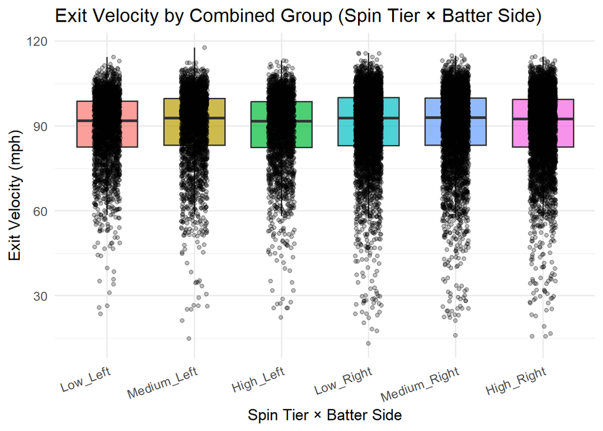

```r
df$Combo <- factor(
  df$Combo,
  levels = c("Low_Left","Medium_Left","High_Left","Low_Right","Medium_Right","High_Right")
)

ggplot(df, aes(Combo, ExitSpeed, fill = Combo)) +
  geom_boxplot(alpha = 0.7, width = 0.7, outlier.shape = NA) +
  # (optional) stripchart look:
  geom_jitter(width = 0.15, alpha = 0.25, size = 1.3) +
  labs(title = "Exit Velocity by Combined Group (Spin Tier × Batter Side)",
       x = "Spin Tier × Batter Side", y = "Exit Velocity (mph)") +
  theme_minimal(base_size = 13) +
  theme(axis.text.x = element_text(angle = 20, hjust = 1)) +
  guides(fill = "none")
```

#### 4.0.2 Mean +_ SE Plot

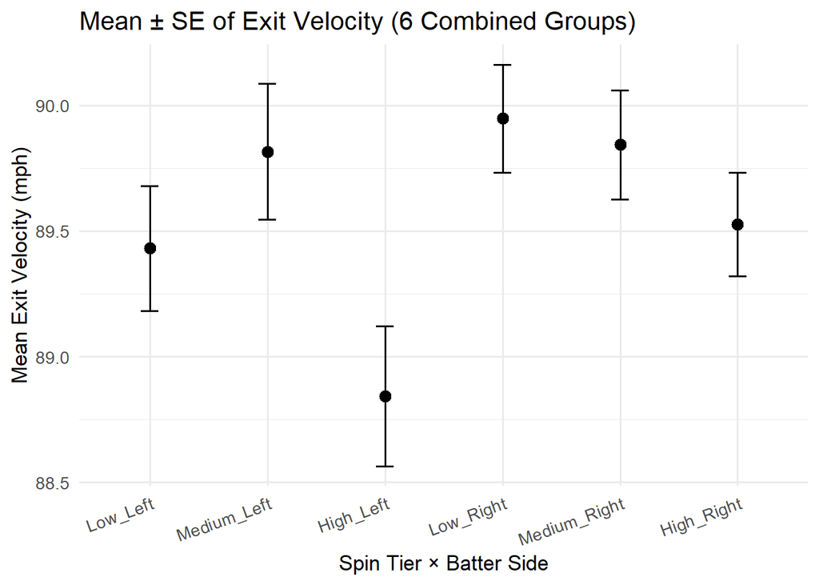

```r
sumdat_combo <- df %>%
  group_by(Combo) %>%
  summarise(
    mean = mean(ExitSpeed),
    se   = sd(ExitSpeed)/sqrt(n()),
    .groups = "drop"
  ) %>%
  mutate(
    Combo = factor(Combo, levels = c("Low_Left","Medium_Left","High_Left",
                                     "Low_Right","Medium_Right","High_Right"))
  )

ggplot(sumdat_combo, aes(Combo, mean)) +
  geom_point(size = 3) +
  geom_errorbar(aes(ymin = mean - se, ymax = mean + se), width = 0.15) +
  labs(title = "Mean ± SE of Exit Velocity (6 Combined Groups)",
       x = "Spin Tier × Batter Side", y = "Mean Exit Velocity (mph)") +
  theme_minimal(base_size = 13) +
  theme(axis.text.x = element_text(angle = 20, hjust = 1))
```